# Errors-in-Variables Regression

Aaron R. Caldwell

Last Updated: 2026-01-21

# Background

Error-in-variables (EIV) models are useful tools to account for measurement error in the independent variable. For studies of agreement, this is particularly useful where there are paired measurements of the paired measurements (X & Y) of the same underlying value (e.g., two assays of the same analyte).

Deming regression is one of the simplest forms of of EIV models promoted by [W. Edwards Deming](https://en.wikipedia.org/wiki/W._Edwards_Deming)[^1]. The first to detail the method were Adcock (1878) followed by Kummell (1879) and Koopmans (1936). The name comes from the popularity of Deming’s book (Deming 1943), and within the field of clinical chemistry, the procedure was simply referred to as “Deming regression” (e.g., Linnet (1990)).

# Deming Regression

## Simple Deming Regression

We can start by creating some fake data to work with.

```r
library(SimplyAgree)

dat = data.frame(
  x = c(7, 8.3, 10.5, 9, 5.1, 8.2, 10.2, 10.3, 7.1, 5.9),
  y = c(7.9, 8.2, 9.6, 9, 6.5, 7.3, 10.2, 10.6, 6.3, 5.2)
)
```

Also, we will assume, based on historical data, that the measurement error ratio is equal to 2.

The data can be run through the `dem_reg` function and the results printed.

```r
dem1 = dem_reg(y ~ x,
               data = dat,
               error.ratio = 2,
               weighted = FALSE)
dem1
```

```
#> Deming Regression with 95% C.I.
#>
#> Call:
#> dem_reg(formula = y ~ x, data = dat, weighted = FALSE, error.ratio = 2,
#>     conf.level = 0.95)
#>
#> Coefficients:
#> (Intercept)           x
#>      0.1285      0.9745
```

The resulting regression line can then be plotted.

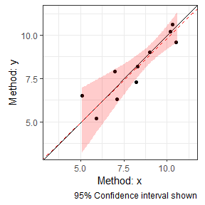

```r
plot(dem1, interval = "confidence")
```

## Model Diagnostics

The assumptions of the Deming regression model, primarily normality and homogeneity of variance, can then be checked with the `check` method for Deming regression results. Both plots appear to be fine with regards to the assumptions.

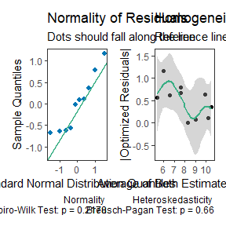

```r
check(dem1)
```

## Fitted Values and Residuals

After fitting a Deming regression model, you can extract the estimated true values and residuals. The `fitted()` function returns the estimated true Y values, accounting for measurement error. The `residuals()` function returns the optimized residuals by default, which correspond to the perpendicular distances from each point to the regression line.

## Weighted Deming Regression

For this example, I will rely upon the “ferritin” data from the `deming` R package.

```r
library(deming)
data('ferritin')

head(ferritin)
```

```
#>   id period old.lot new.lot
#> 1  1      1       1       1
#> 2  2      1       3       3
#> 3  3      1      10       9
#> 4  4      1      13      11
#> 5  5      1      13      12
#> 6  6      1      15      13
```

Let me demonstrate the problem with using simple Deming regression when the weights are helpful. When we look at the two plots below, we can see there is severe problem with using the “un-weighted” model.

```r
dem2 = dem_reg(
  old.lot ~ new.lot,
  data = ferritin,
  weighted = FALSE
)
summary(dem2)
```

```
#> Deming Regression with 95% C.I.
#>
#> Call:
#> dem_reg(formula = old.lot ~ new.lot, data = ferritin, weighted = FALSE,
#>     conf.level = 0.95)
#>
#> Coefficients:
#>             coef      bias      se  df lower.ci upper.ci      t p.value
#> Intercept 5.2157 -0.235818 2.18603 160   0.8985    9.533  2.386 0.01821
#> Slope     0.9637  0.002597 0.02505 160   0.9143    1.013 -1.448 0.14949
#>
#> 160 degrees of freedom
#> Error variance ratio (lambda): 1.0000
```

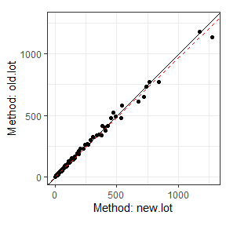

```r
plot(dem2)
```

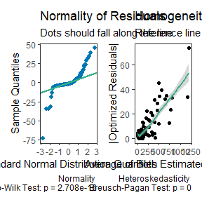

```r
check(dem2)
```

Now, let us see what happens when `weighted` is set to TRUE.

```r
dem3 = dem_reg(
  old.lot ~ new.lot,
  data = ferritin,
  weighted = TRUE
)
summary(dem3)
```

```
#> Weighted Deming Regression with 95% C.I.
#>
#> Call:
#> dem_reg(formula = old.lot ~ new.lot, data = ferritin, weighted = TRUE,
#>     conf.level = 0.95)
#>
#> Coefficients:
#>               coef       bias       se  df lower.ci upper.ci       t   p.value
#> Intercept -0.02616  0.0065148 0.033219 160 -0.09176  0.03945 -0.7874 4.322e-01
#> Slope      1.03052 -0.0001929 0.006262 160  1.01815  1.04288  4.8729 2.626e-06
#>
#> 160 degrees of freedom
#> Error variance ratio (lambda): 1.0000
```

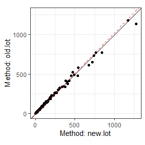

```r
plot(dem3)
```

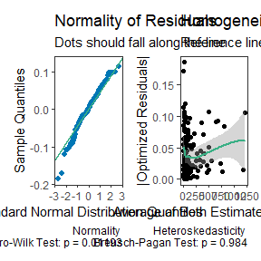

```r
check(dem3)
```

The weighted model provides a better fit.

# Passing-Bablok Regression

## When to Use Passing-Bablok

Passing-Bablok regression is particularly useful when:

- Both X and Y are measured with error
- You want a robust method not sensitive to outliers
- The relationship is assumed to be linear
- X and Y are highly positively correlated

## Basic Usage

The `pb_reg()` function implements three variants of Passing-Bablok regression:

```r
# Create example data
pb_data <- data.frame(
  method1 = c(69.3, 27.1, 61.3, 50.8, 34.4, 92.3, 57.5, 45.5, 33.3, 60.9,
              56.3, 49.9, 89.7, 28.9, 96.3, 76.6, 83.2, 79.4, 51.7, 32.5,
              99.1, 14.2, 84.1, 48.8, 61.5, 84.9, 93.2, 73.8, 62.1, 98.6),
  method2 = c(69.1, 26.7, 61.4, 51.2, 34.7, 88.5, 57.9, 45.1, 33.4, 60.8,
              66.5, 48.2, 88.3, 29.3, 96.4, 77.1, 82.7, 78.9, 51.6, 28.8,
              98.4, 12.7, 83.6, 47.3, 61.2, 84.6, 92.1, 73.4, 61.9, 98.6)
)

# Fit Passing-Bablok regression
pb1 <- pb_reg(method2 ~ method1, data = pb_data)
pb1
```

```
#> Passing-Bablok (scissors) with 95% C.I.
#>
#> Call:
#> pb_reg(formula = method2 ~ method1, data = pb_data)
#>
#> Coefficients:
#> (Intercept)     method1
#>     0.09622     0.99440
#>
#> Kendall's Tau (H0: tau <= 0):
#>   tau:       0.9632
#>   p-value:   0.0000
#>
#> CUSUM Linearity Test:
#>   Test stat: 1.0000
#>   p-value:   0.1844
```

## Summary and Plots

The summary provides details about the regression coefficients and diagnostic tests:

```r
summary(pb1)
```

```
#> Passing-Bablok (scissors) with 95% C.I.
#>
#> Call:
#> pb_reg(formula = method2 ~ method1, data = pb_data)
#>
#> Coefficients:
#>        term    coef       se lower.ci upper.ci df null_value reject_h0
#> 1 Intercept 0.09622 0.390603  -0.7206   0.8105 28          0     FALSE
#> 2   method1 0.99440 0.005918   0.9840   1.0072 28          1     FALSE
#>
#> 28 degrees of freedom
#> Error variance ratio (lambda): 1.0000
```

The `plot()` method displays the regression line with data:

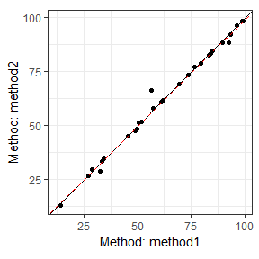

```r
plot(pb1)
```

## Model Diagnostics

The `check()` method provides diagnostic plots specific to Passing-Bablok regression, including the CUSUM linearity test and Kendall’s tau correlation:

[figure not shown]

```r
check(pb1)
```

## Bootstrap Confidence Intervals

For more robust inference, especially with the “invariant” or “scissors” methods, bootstrap confidence intervals are recommended:

```r
pb2 <- pb_reg(method2 ~ method1,
              data = pb_data,
              replicates = 999)
summary(pb2)
```

```
#> Passing-Bablok (scissors) with 95% C.I.
#>
#> Call:
#> pb_reg(formula = method2 ~ method1, data = pb_data, replicates = 999)
#>
#> Coefficients:
#>        term    coef       se lower.ci upper.ci df null_value reject_h0
#> 1 Intercept 0.09622 0.089867 -0.08681   0.2655 28          0     FALSE
#> 2   method1 0.99440 0.001305  0.99192   0.9970 28          1      TRUE
#>
#> 28 degrees of freedom
#> Error variance ratio (lambda): 1.0000
#>
#>
#> Bootstrap CIs based on 999 resamples
```

# Joint Confidence Regions

A theoretically valid, but still experimental, enhancement to the `dem_reg` and `pb_reg` functions is the addition of **joint confidence regions** for the slope and intercept parameters. Traditional confidence intervals treat each parameter separately, but in regression analysis, these parameters are correlated.

Joint confidence regions account for this correlation by creating an elliptical region in the (intercept, slope) parameter space. This approach, promoted by Sadler (2010), provides several advantages:

- **Higher Statistical Power**: The ellipse typically requires 20-50% fewer samples than traditional confidence intervals to detect the same bias
- **Accounts for Parameter Correlation**: When the measurement range is narrow, slope and intercept are highly negatively correlated
- **More Appropriate Test**: Testing against a point (e.g., slope=1, intercept=0) is naturally done with a region, not separate intervals

The power advantage is most pronounced when the ratio of maximum to minimum X values is small (< 10:1), which is common in clinical method comparisons.

## Visualizing the Joint Confidence Region

The `plot_joint()` function allows visualization of the confidence region in parameter space:

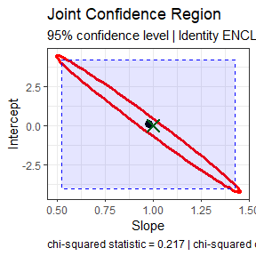

```r
plot_joint(dem1,
           ideal_slope = 1,
           ideal_intercept = 0,
           show_intervals = TRUE)
```

This plot shows:

- The **red ellipse**: Joint confidence region
- The **blue rectangle**: Traditional confidence intervals
- The **black dot**: Estimated (intercept, slope)
- The **green/red X**: Ideal point (whether enclosed or not)

Notice how the ellipse is smaller than the rectangle, especially in the directions that matter for detecting bias.

For Passing-Bablok regression, bootstrap resampling must be used to obtain the variance-covariance matrix needed for the joint confidence region:

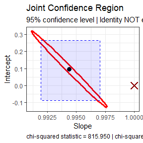

```r
plot_joint(pb2)
```

## Joint Hypothesis Test

The `joint_test()` function provides a formal hypothesis test for whether the identity line (slope = 1, intercept = 0) falls within the joint confidence region:

```r
joint_test(dem1)
```

```
#>
#>  Joint Confidence Region Test (H0: intercept = 0, slope = 1)
#>
#> data:  y ~ x
#> X-squared = 0.21666, df = 2, p-value = 0.8973
#> alternative hypothesis: true intercept and slope are not equal to the null values
#> null values:
#> intercept     slope
#>         0         1
#> sample estimates:
#> intercept     slope
#> 0.1284751 0.9744516
```

This returns an `htest` object with the Mahalanobis distance (chi-squared statistic) and p-value. The test can also be applied to Passing-Bablok models fitted with bootstrap:

```r
joint_test(pb2)
```

```
#>
#>  Joint Confidence Region Test (H0: intercept = 0, slope = 1)
#>
#> data:  method2 ~ method1
#> X-squared = 815.95, df = 2, p-value < 2.2e-16
#> alternative hypothesis: true intercept and slope are not equal to the null values
#> null values:
#> intercept     slope
#>         0         1
#> sample estimates:
#>  intercept      slope
#> 0.09621849 0.99439776
```

# Theoretical Details

## Deming Calculative Approach

Deming regression assumes paired measures ($x_i, \space y_i$) are each measured with error.

$$x_i = X_i + \epsilon_i$$

$$y_i = Y_i + \delta_i$$

We can then measure the relationship between the two variables with the following model.

$$\hat Y_i = \beta_0 + \beta_1 \cdot \hat X_i$$

Traditionally there are 2 null hypotheses.

First, the intercept is equal to zero:

$$H_0: \beta_0 = 0 \space vs. \space H_1: \beta_0 \ne 0$$

Second, that the slope is equal to one:

$$H_0: \beta_1 = 1 \space vs. \space H_1: \beta_0 \ne 1$$

# Joint Confidence Region Calculative Approach

The joint $(1-\alpha) \times 100\%$ confidence region for $(\beta_0, \beta_1)$ is defined as:

$$(\hat{\beta} - \beta_0)^T V^{-1} (\hat{\beta} - \beta_0) \leq
\chi^2_{2,\alpha}$$

Where:

- $\hat{\beta}$ = estimated parameters $(\hat{\beta}_0, \hat{\beta}_1)$
- $\beta_0$ = hypothesized parameters (e.g., $(0, 1)$ for identity)
- $V$ = variance-covariance matrix
- $\chi^2_{2,\alpha}$ = chi-square critical value with 2 degrees of freedom

This forms an ellipse in parameter space that accounts for the correlation between slope and intercept.

## Measurement Error

A Deming regression model also assumes the measurement error ($\sigma^2$) ratio is constant.

$$\lambda = \frac{\sigma^2_\epsilon}{\sigma^2_\delta}$$

In `SimplyAgree`, the error ratio can be set with the `error.ratio` argument. It defaults to 1, but can be changed by the user. If replicate measures are taken, then the user can use the `id` argument to indicate which measures belong to which subject/participant. The measurement error, and the error ratio, will then be estimated from the data itself.

If the data was not measured in replicate then the error ratio ($\lambda$) can be estimated from the coefficient of variation (if that data is available) and the mean of x and y ($\bar x, \space \bar y$).

$$\lambda = \frac{(CV_y \cdot \bar y)^2}{(CV_x \cdot \bar x)^2}$$

## Weights

In some cases the variance of X and Y may increase proportional to the true value of the measure. In these cases, it may be prudent to use “weighted” Deming regression models. The weights used in `SimplyAgree` are the same as those suggested by Linnet (1993).

$$\hat w_i = \frac{1}{ [ \frac{x_i + \lambda \cdot y_i}{1 + \lambda}]^2}$$

Weights can also be provided through the `weights` argument. If weighted Deming regression is not selected (`weighted = FALSE`), the weights for each observation is equal to 1.

The estimated mean of X and Y are then estimated as the following.

$$\bar x_w = \frac{\Sigma^{N}_{i=1} \hat w_i \cdot x_i}{\Sigma^{N}_{i=1}
\hat w_i}$$

$$\bar y_w = \frac{\Sigma^{N}_{i=1} \hat w_i \cdot y_i}{\Sigma^{N}_{i=1}
\hat w_i}$$

## Estimating the Slope and Intercept

First, there are 3 components ($v_x, \space v_y, \space cov_{xy}$)

$$v_x = \Sigma_{i=1}^N \space \hat w_i \cdot (x_i- \bar x_w)^2$$
$$v_y = \Sigma_{i=1}^N \space \hat w_i \cdot (y_i- \bar y_w)^2$$
$$cov_{xy} = \Sigma_{i=1}^N \space \hat w_i \cdot (x_i- \bar x_w) \cdot
(y_i- \bar y_w)$$

The slope ($b_1$) can then be estimated with the following equation.

$$b_1 = \frac{(\lambda \cdot v_y - v_x) + \sqrt{(v_x-\lambda \cdot v_y)^2
+ 4 \cdot \lambda \cdot cov_{xy}^2}}{2 \cdot \lambda \cdot cov_{xy}}$$

The intercept ($b_0$) can then be estimated with the following equation.

$$b_0 = \bar y_w - b_1 \cdot \bar x_w$$

The standard errors of b1 and b0 are both estimated using a jackknife method (detailed by Linnet (1990)).

# References

Adcock, R J. 1878. “A Problem in Least Squares.” *The Analyst* 5 (2): 53. https://doi.org/10.2307/2635758.

Deming, W E. 1943. *Statistical Adjustment of Data*. Wiley.

Koopmans, Tjalling Charles. 1936. *Linear Regression Analysis of Economic Time Series*. Vol. 20. DeErven F. Bohn, Haarlem, Netherlands.

Kummell, C H. 1879. “Reduction of Observation Equations Which Contain More Than One Observed Quantity.” *The Analyst* 6 (4): 97. https://doi.org/10.2307/2635646.

Linnet, Kristian. 1990. “Estimation of the Linear Relationship Between the Measurements of Two Methods with Proportional Errors.” *Statistics in Medicine* 9 (12): 1463–73. https://doi.org/10.1002/sim.4780091210.

———. 1993. “Evaluation of Regression Procedures for Methods Comparison Studies.” *Clinical Chemistry* 39 (3): 424–32.

Sadler, W A. 2010. “Joint Parameter Confidence Regions Improve the Power of Parametric Regression in Method-Comparison Studies.” *Accreditation Qual. Assur.* 15 (10): 547–54.

[^1]: Deming was a titan of the fields of statistics and engineering and I would highly recommend reading some of his academic work and books